# OPPE Report

Steven P. Sanderson II, MPH - Data Scientist/IT Manager

24 July, 2020

# 1 Information About Report

This report gives information on a providers performance in regards to a few things. The items this report covers are:

- Average Lengh of Stay
  - History with Linear Trend
  - Z-Score with Linear Trend
  - CMI and SOI with Linear Trend
  - Excess days from Benchmark
  - Excess Days Anomaly Analysis
  - Outliers are excluded, see Appendix
- Readmissions
  - History with Linear Trend
  - Z-Score with Linear Trend
  - CMI and SOI with Linear Trend
  - Excess Rate from Benchmark
  - Excess Readmit Rate Anomaly Analysis
- Denials
  - All denied cases (Government/Commercial/etc)
  - Year over Year Pecent Change in Dollars
  - Dollars Denied by Year
  - Cumulative Dollars Denied
  - Cumulative Dollars Recovered
  - Recovery Percent by Year
- CPOE
  - Review of CPOE, Telephone, Verbal and Written
  - Trending
  - Cluster Analysis
- Consult Network
  - Network Consult Graph
  - Consults Ordered by Provider
  - Consult Order Percentage by Attending/Non-Attending

Important note about ALOS Data:

- The inpatient account must have positive total charges on it
- The following Medical Staff Departments are excluded:
  - Anesthesiology
  - Emergency Department
  - Pathology

The following MS-DRG numbers are excluded:

| drg | drg_name |
| --- | --- |
| 0 | DRG UNASSIGNED |
| 981 | MDC P,EXTENSIVE O.R. PROCEDURE UNRELATED TO PRINCIPAL DIAGNOSIS W MCC |
| 982 | MDC P,EXTENSIVE O.R. PROCEDURE UNRELATED TO PRINCIPAL DIAGNOSIS W CC |
| 983 | MDC P,EXTENSIVE O.R. PROCEDURE UNRELATED TO PRINCIPAL DIAGNOSIS W/O CC |
| 984 | MDC P,PROSTATIC O.R. PROCEDURE UNRELATED TO PRINCIPAL DIAGNOSIS W MCC |
| 985 | MDC P,PROSTATIC O.R. PROCEDURE UNRELATED TO PRINCIPAL DIAGNOSIS W CC |
| 986 | MDC P,PROSTATIC O.R. PROCEDURE UNRELATED TO PRINCIPAL DIAGNOSIS W/O CC |
| 987 | MDC P,NON-EXTENSIVE O.R. PROC UNRELATED TO PRINCIPAL DIAGNOSIS W MCC |
| 988 | MDC P,NON-EXTENSIVE O.R. PROC UNRELATED TO PRINCIPAL DIAGNOSIS W CC |
| 989 | MDC P,NON-EXTENSIVE O.R. PROC UNRELATED TO PRINCIPAL DIAGNOSIS W/O CC/ |
| 998 | MDC ,PRINCIPAL DIAGNOSIS INVALID AS DISCHARGE DIAGNOSIS |

Import note about Readmit Data:

- Only discharge dispositions of AHR and ATW (Home & Home - Adult Home - Assisted Living) are included
- Certain APR-DRG’s are excluded, see Appendix

# 2 Data Exploration

## 2.1 Discharges and ALOS data

| Provider | Total Discharges | ALOS | ELOS | Excess |
| --- | --- | --- | --- | --- |
| Choudhury Shahin Ara | 515 | 7.27 | 6.19 | 1.08 |

## 2.2 Discharges and Readmit Rate data

| Provider | Total Discharges | Readmit Rate % | Expected Rate % | Excess Rate % | ALOS | Mean Days to Readmit |
| --- | --- | --- | --- | --- | --- | --- |
| Choudhury Shahin Ara | 326 | 11% | NA | NA | 5.89 | 10.5 |

## 2.3 Denial Data

Denial data is gathered by a patients admit date. The data is gathered from today minus 5 years, starting on the first of the year. For example if today is 2019-11-05 then the start date is 2014-01-01.

| IP/OP | Admits | Denials | ALOS | Avg Days Denied | Dollars Denied | Dollars Recovered | Total Charges | % Cases Denied | % Dollars Denied | % Recovered |
| --- | --- | --- | --- | --- | --- | --- | --- | --- | --- | --- |
| I | 1903 | 137 | 6.18 | 2.99 | $1,063,781 | $423,844 | $125,973,767 | 7.2% | 0.84% | 40% |
| O | 179 | 0 | 0.00 | 0.00 | $0 | $0 | $3,762,734 | 0.0% | 0.00% | 0% |

# 3 CPOE Order Plots

## 3.1 Order Use Percentage

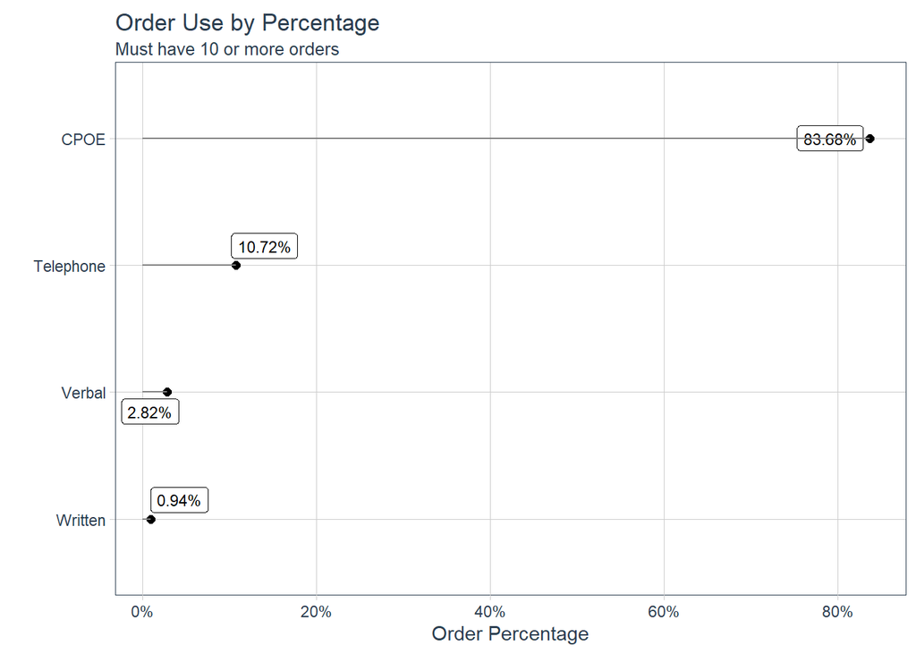

## 3.2 Order Total Orders Trend

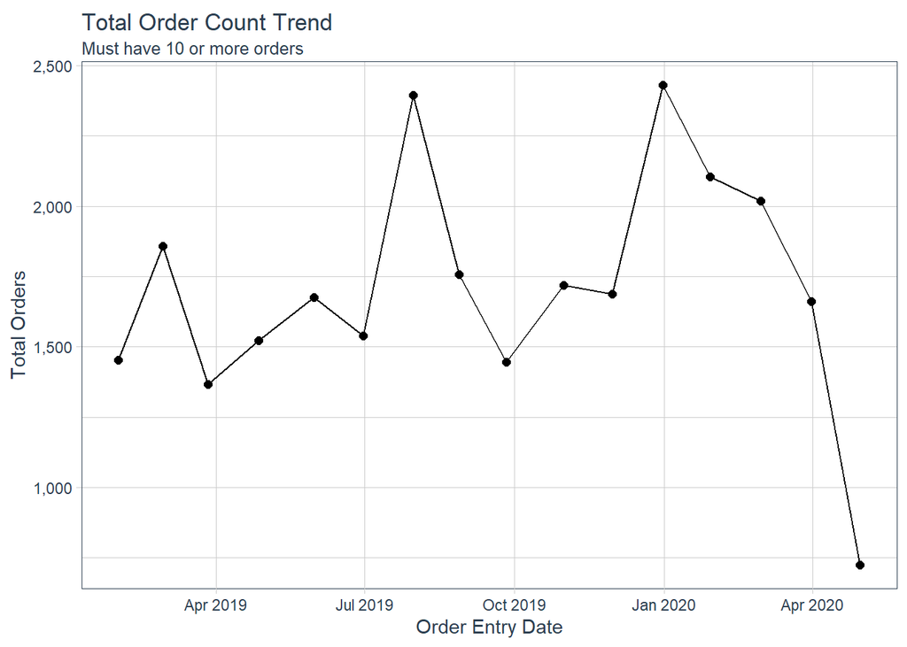

## 3.3 Order Percentage Trend

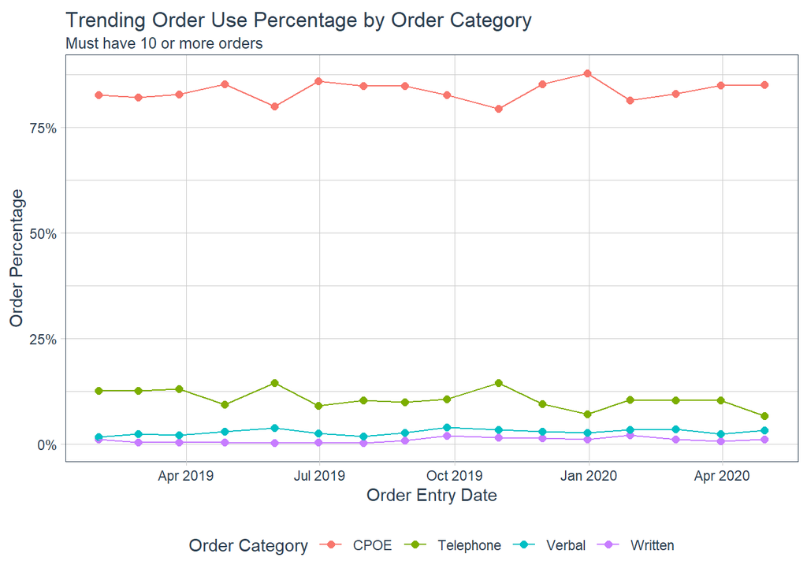

# 4 CPOE Order Clustering

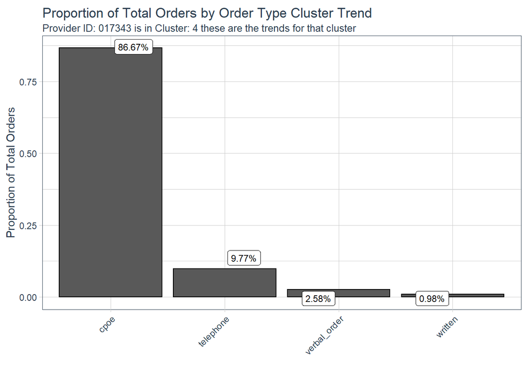

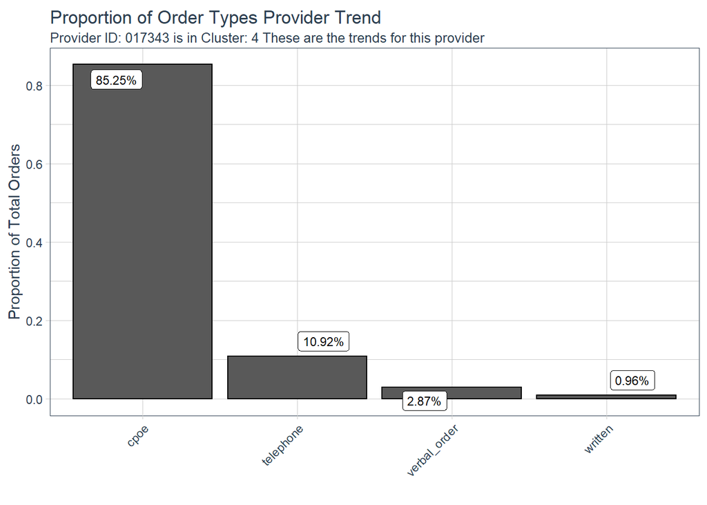

# 5 Length of Stay Trends

## 5.1 Alos vs. Elos Trend

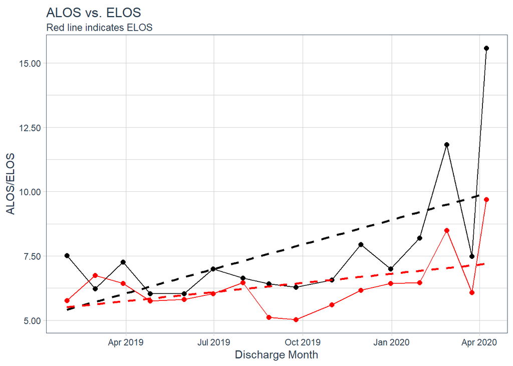

## 5.2 Excess Days Trend

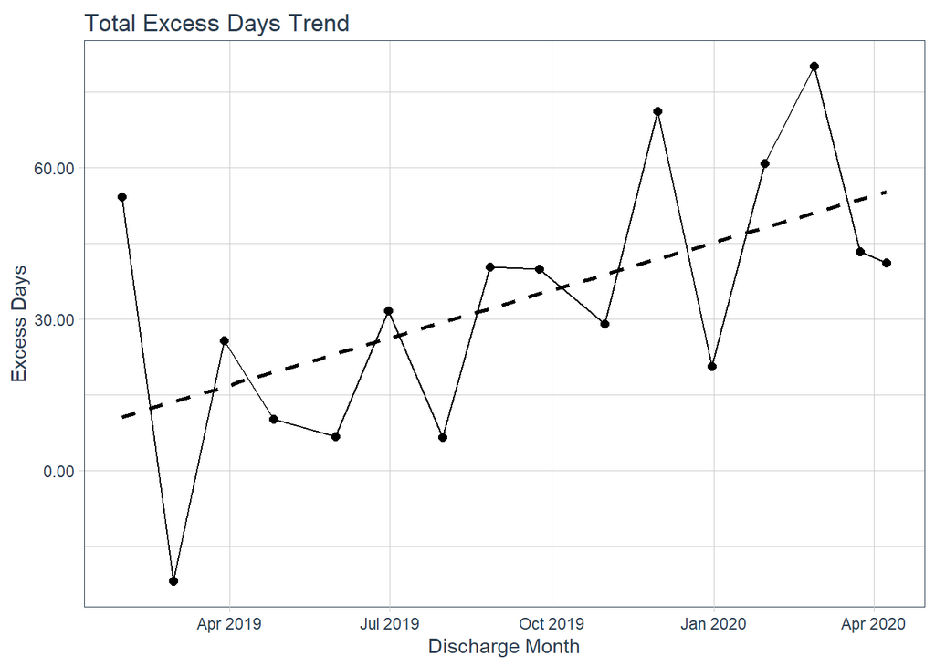

## 5.3 CMI and SOI Trend

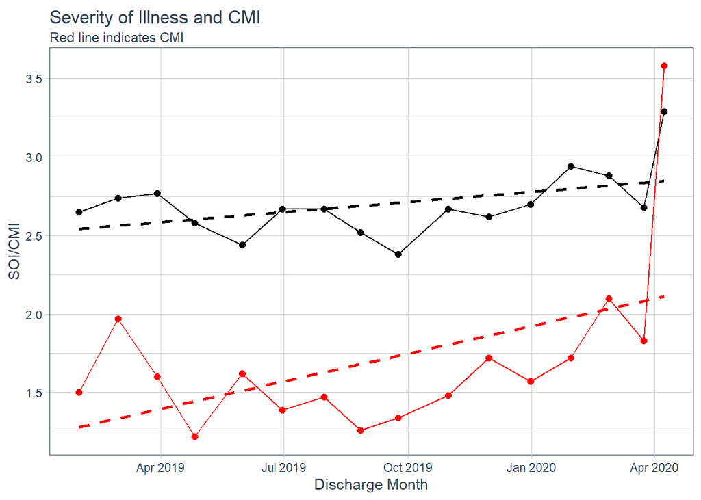

## 5.4 Z-Score Plot

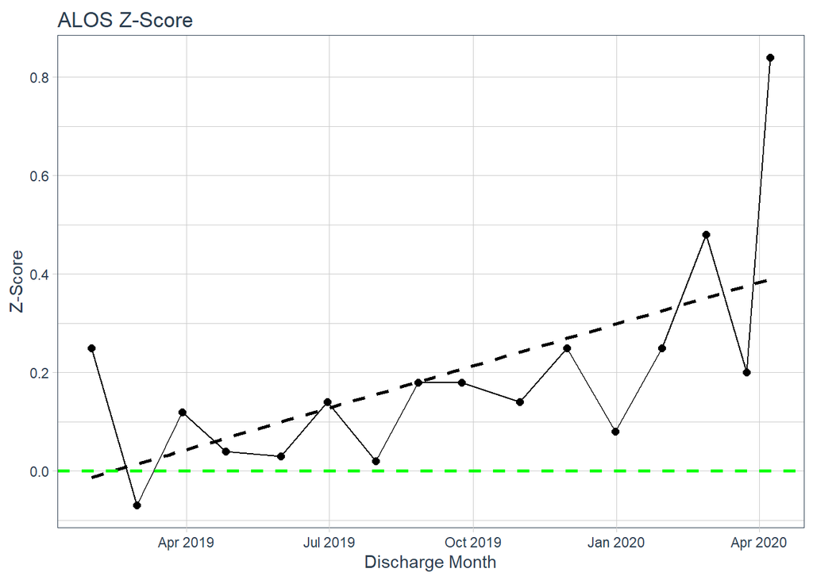

## 5.5 ALOS SOI Facet

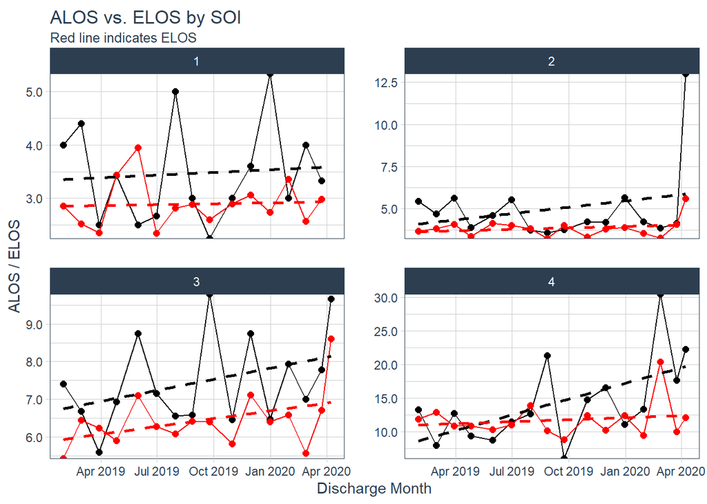

## 5.6 Excess by SOI

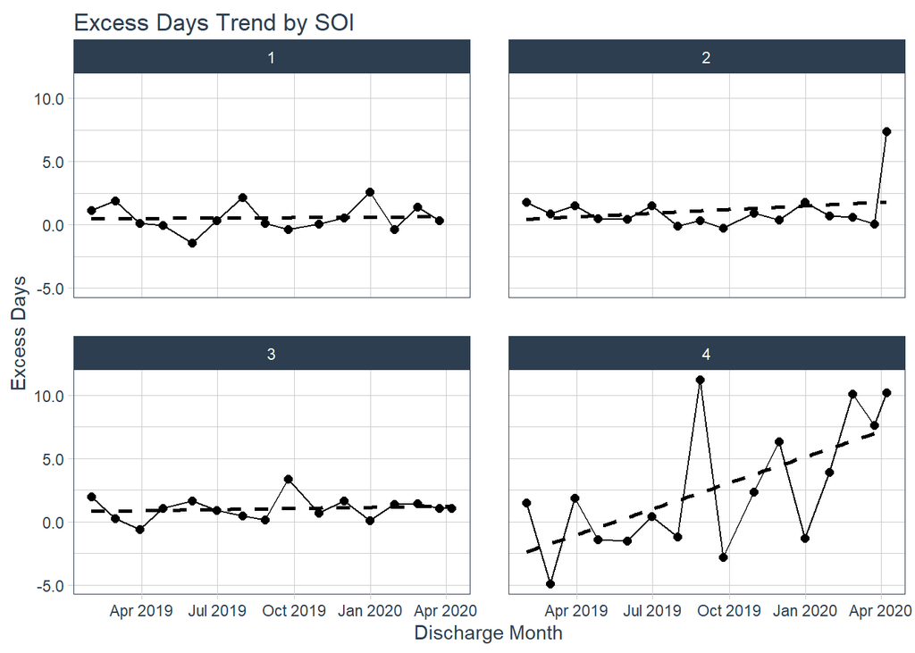

## 5.7 LOS Anomalies

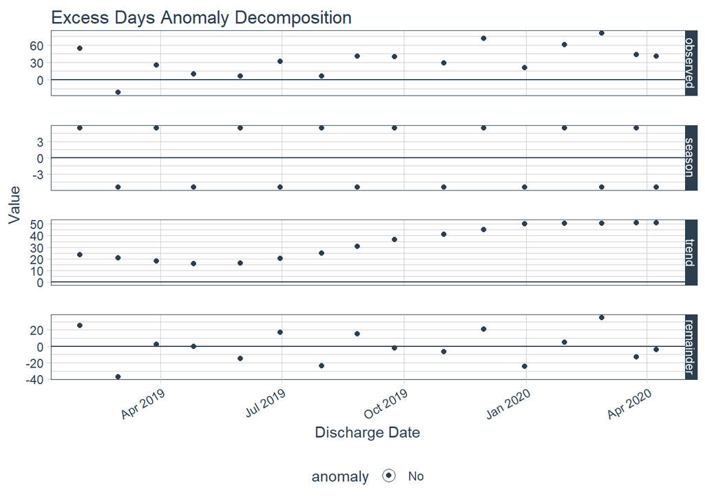

# 6 Readmission Trends

## 6.1 Actual v Expected

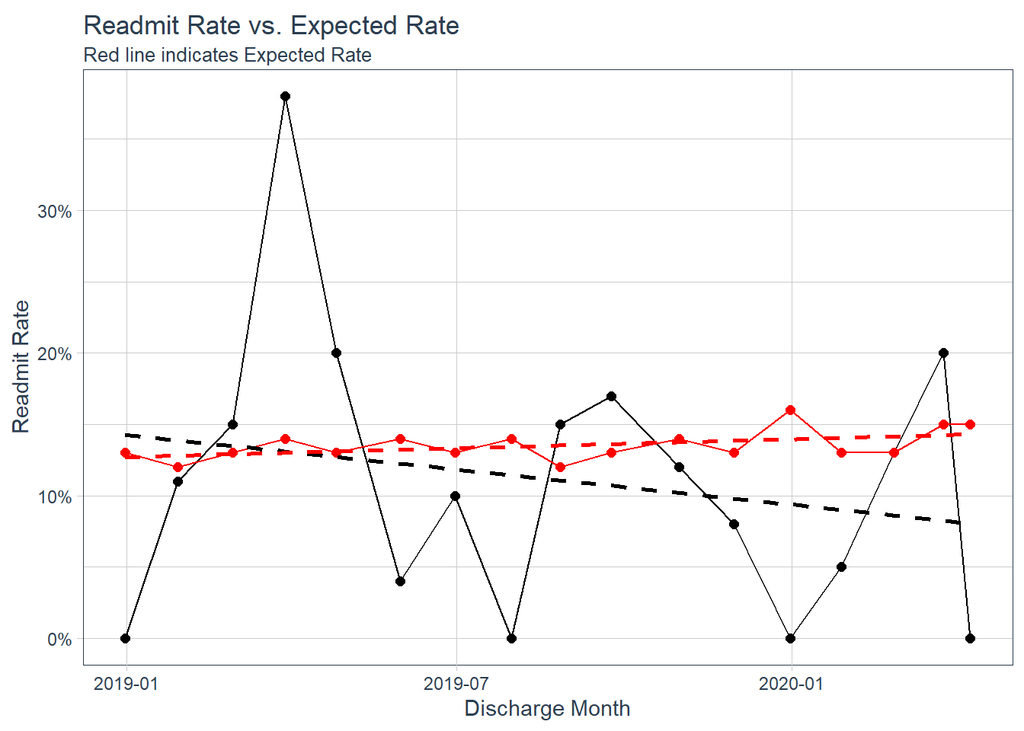

## 6.2 Excess Trend

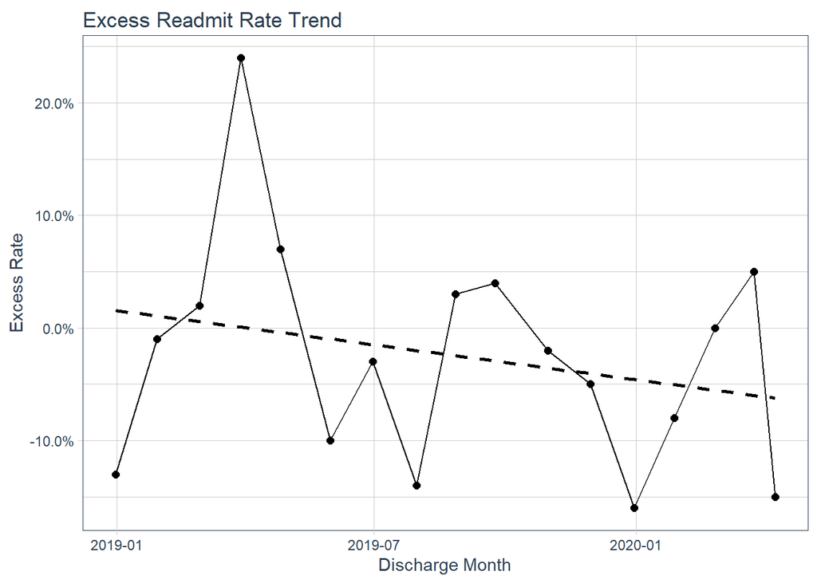

## 6.3 SOI/CMI

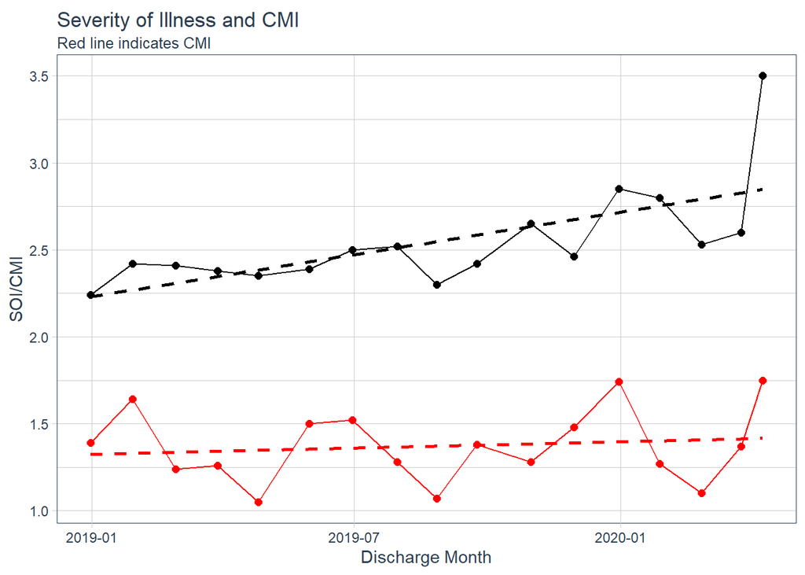

## 6.4 Z-Score Plot

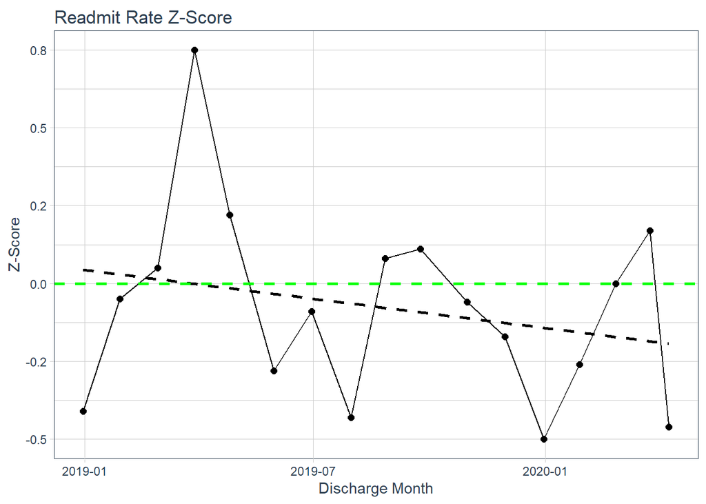

## 6.5 Readmit Facet by SOI

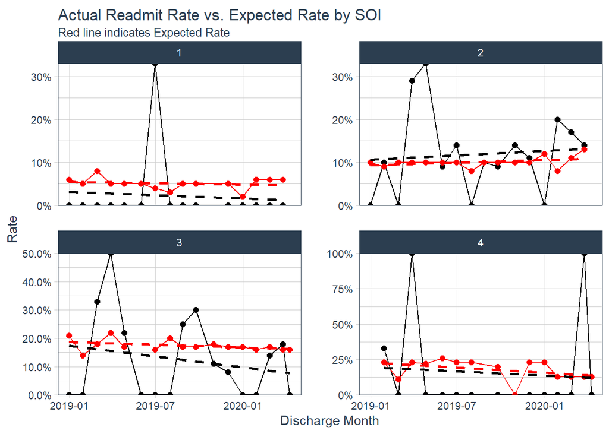

## 6.6 Excess by SOI

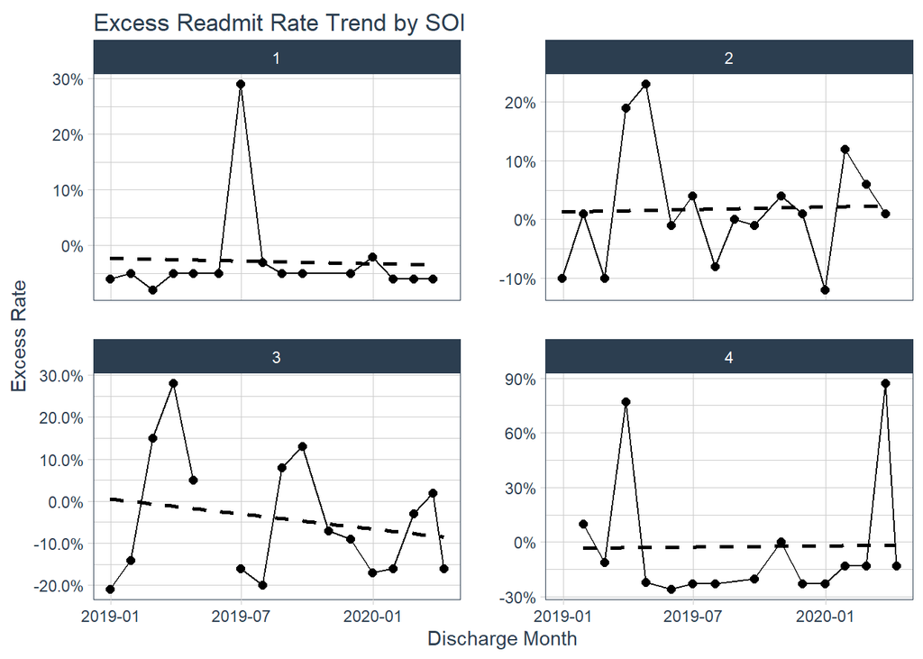

## 6.7 Readmit Anomalies

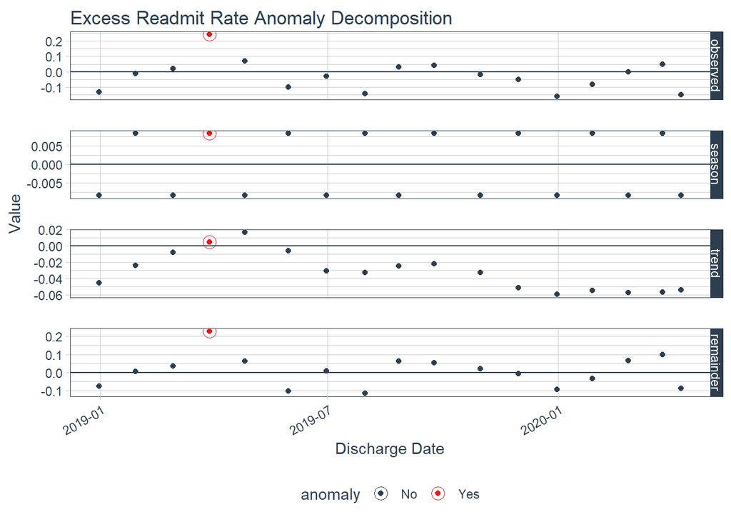

# 7 Gartner Magic Chart

Shows data collapsed by week. Excess Readmit Rate on the y axis and Excess LOS on the x axis. A provider wants to be in the lower left quadrant where both x and y are negative.

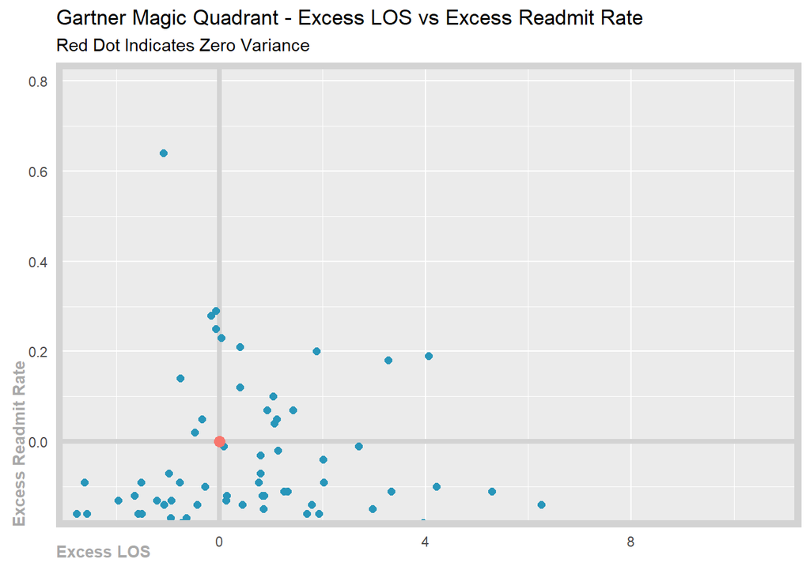

# 8 Denials

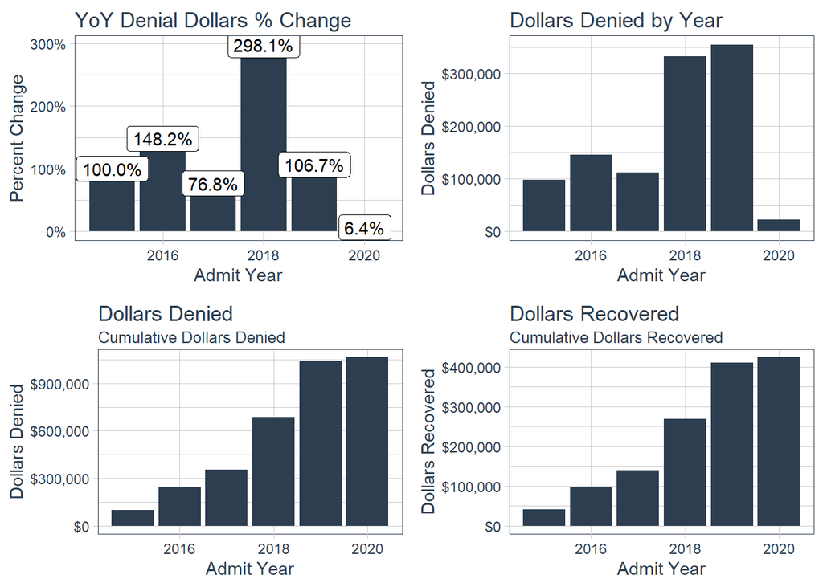

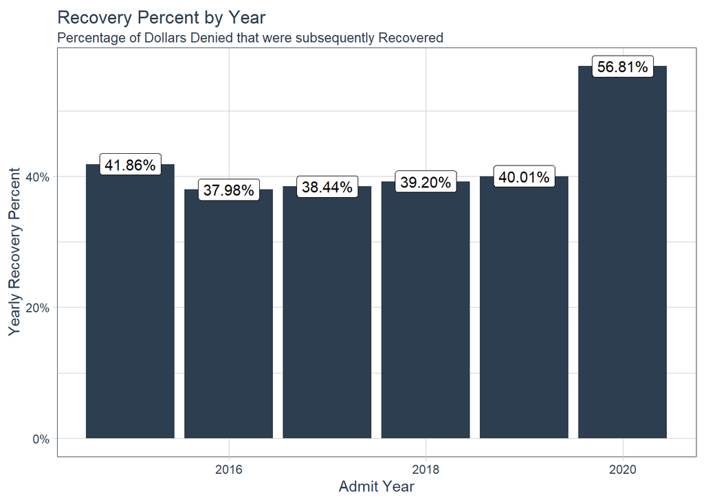

# 9 Consultant Network

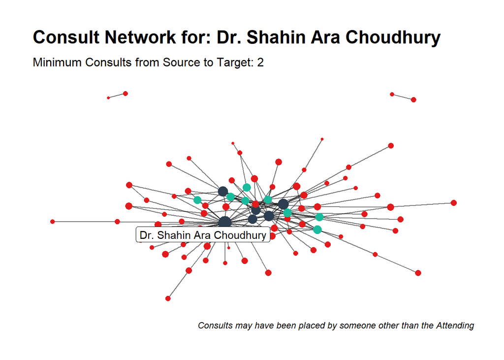

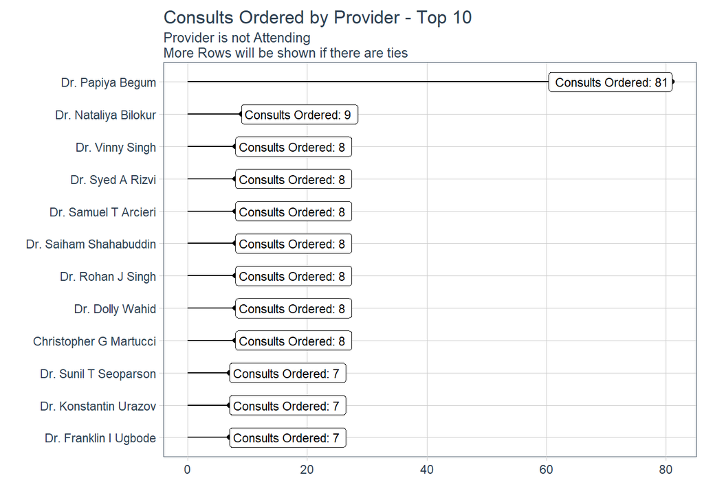

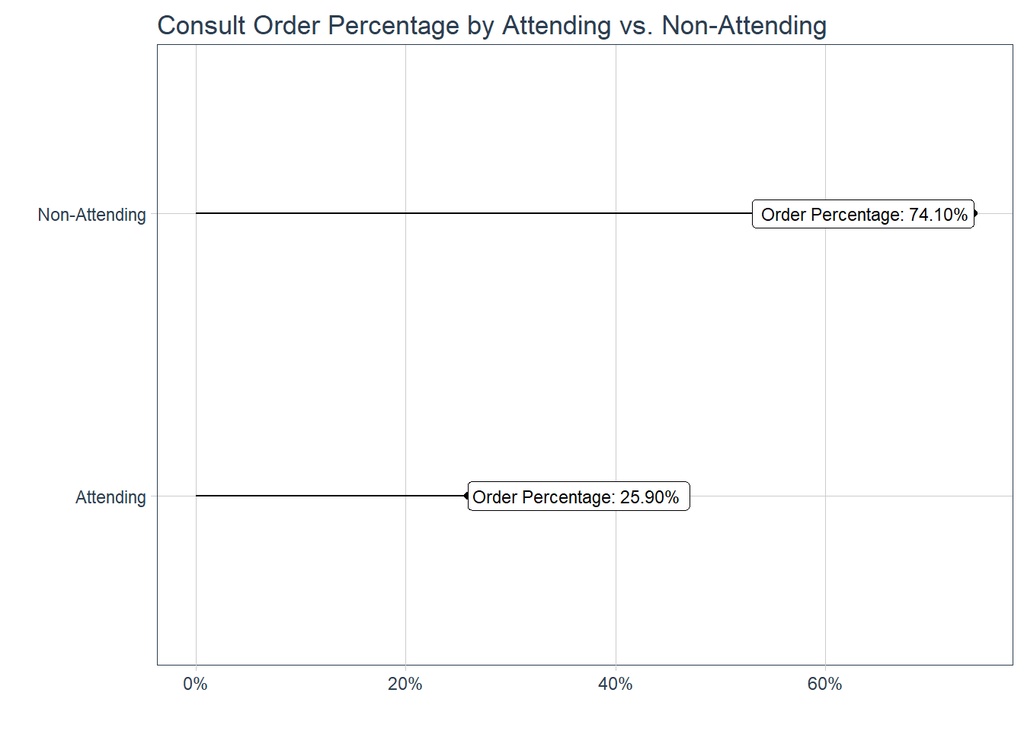

# 10 Appendix

#### 10.0.0.1 APR-DRG Thresholds

**Click to see APR-DRG Thresholds**

| APR DRG | Description | Threshold |
| --- | --- | --- |
| 1 | LIVER TRANSPLANT &/OR INTESTINAL TRANSPLANT | 235 |
| 2 | HEART &/OR LUNG TRANSPLANT | 759 |
| 3 | BONE MARROW TRANSPLANT | 122 |
| 4 | TRACHEOSTOMY W MV 96+ HOURS W EXTENSIVE PROCEDURE OR ECMO | 504 |
| 5 | TRACHEOSTOMY W MV 96+ HOURS W/O EXTENSIVE PROCEDURE | 223 |
| 6 | PANCREAS TRANSPLANT | 139 |
| 20 | CRANIOTOMY FOR TRAUMA | 83 |
| 21 | CRANIOTOMY EXCEPT FOR TRAUMA | 89 |
| 22 | VENTRICULAR SHUNT PROCEDURES | 76 |
| 23 | SPINAL PROCEDURES | 68 |
| 24 | EXTRACRANIAL VASCULAR PROCEDURES | 39 |
| 26 | OTHER NERVOUS SYSTEM & RELATED PROCEDURES | 71 |
| 40 | SPINAL DISORDERS & INJURIES | 143 |
| 41 | NERVOUS SYSTEM MALIGNANCY | 84 |
| 42 | DEGENERATIVE NERVOUS SYSTEM DISORDERS EXC MULT SCLEROSIS | 92 |
| 43 | MULTIPLE SCLEROSIS & OTHER DEMYELINATING DISEASES | 42 |
| 44 | INTRACRANIAL HEMORRHAGE | 73 |
| 45 | CVA & PRECEREBRAL OCCLUSION W INFARCT | 44 |
| 46 | NONSPECIFIC CVA & PRECEREBRAL OCCLUSION W/O INFARCT | 27 |
| 47 | TRANSIENT ISCHEMIA | 15 |
| 48 | PERIPHERAL, CRANIAL & AUTONOMIC NERVE DISORDERS | 35 |
| 49 | BACTERIAL & TUBERCULOUS INFECTIONS OF NERVOUS SYSTEM | 83 |
| 50 | NON-BACTERIAL INFECTIONS OF NERVOUS SYSTEM EXC VIRAL MENINGI | 89 |
| 51 | VIRAL MENINGITIS | 24 |
| 52 | NONTRAUMATIC STUPOR & COMA | 60 |
| 53 | SEIZURE | 25 |
| 54 | MIGRAINE & OTHER HEADACHES | 15 |
| 55 | HEAD TRAUMA W COMA >1 HR OR HEMORRHAGE | 50 |
| 56 | BRAIN CONTUSION/LACERATION & COMPLICATED SKULL FX, COMA < 1 | 55 |
| 57 | CONCUSSION, CLOSED SKULL FX NOS,UNCOMPLICATED INTRACRANIAL I | 13 |

[output cut: 293 more lines]

#### 10.0.0.2 APR-DRG Exclusions

**Click to see APR-DRG Exclusions for Readmits**

| APR DRG | Description |
| --- | --- |
| 41 | NERVOUS SYSTEM MALIGNANCY |
| 53 | SEIZURE |
| 70 | ORBITAL PROCEDURES |
| 73 | EYE PROCEDURES EXCEPT ORBIT |
| 80 | ACUTE MAJOR EYE INFECTIONS |
| 82 | EYE DISORDERS EXCEPT MAJOR INFECTIONS |
| 110 | EAR, NOSE, MOUTH, THROAT, CRANIAL/FACIAL MALIGNANCIES |
| 131 | CYSTIC FIBROSIS - PULMONARY DISEASE |
| 136 | RESPIRATORY MALIGNANCY |
| 240 | DIGESTIVE MALIGNANCY |
| 248 | MAJOR GASTROINTESTINAL & PERITONEAL INFECTIONS |
| 281 | MALIGNANCY OF HEPATOBILIARY SYSTEM & PANCREAS |
| 308 | HIP & FEMUR FRACTURE REPAIR |
| 309 | OTHER SIGNIFICANT HIP & FEMUR SURGERY |
| 343 | MUSCULOSKELETAL MALIGNANCY & PATHOL FRACTURE D/T MUSCSKEL MA |
| 382 | MALIGNANT BREAST DISORDERS |
| 384 | CONTUSION, OPEN WOUND & OTHER TRAUMA TO SKIN & SUBCUTANEOUS |
| 442 | KIDNEY & URINARY TRACT PROCEDURES FOR MALIGNANCY |
| 461 | KIDNEY & URINARY TRACT MALIGNANCY |
| 463 | KIDNEY & URINARY TRACT INFECTIONS |
| 500 | MALIGNANCY, MALE REPRODUCTIVE SYSTEM |
| 530 | FEMALE REPRODUCTIVE SYSTEM MALIGNANCY |
| 580 | NEONATE, TRANSFERRED <5 DAYS OLD, NOT BORN HERE |
| 581 | NEONATE, TRANSFERRED < 5 DAYS OLD, BORN HERE |
| 583 | NEONATE W ECMO |
| 588 | NEONATE BWT <1500G W MAJOR PROCEDURE |
| 589 | NEONATE BWT <500G OR GA <24 WEEKS |
| 591 | NEONATE BIRTHWT 500-749G W/O MAJOR PROCEDURE |
| 593 | NEONATE BIRTHWT 750-999G W/O MAJOR PROCEDURE |
| 602 | NEONATE BWT 1000-1249G W RESP DIST SYND/OTH MAJ RESP OR MAJ |
| 603 | NEONATE BIRTHWT 1000-1249G W OR W/O OTHER SIGNIFICANT CONDIT |
| 607 | NEONATE BWT 1250-1499G W RESP DIST SYND/OTH MAJ RESP OR MAJ |
| 608 | NEONATE BWT 1250-1499G W OR W/O OTHER SIGNIFICANT CONDITION |
| 609 | NEONATE BWT 1500-2499G W MAJOR PROCEDURE |
| 611 | NEONATE BIRTHWT 1500-1999G W MAJOR ANOMALY |
| 612 | NEONATE BWT 1500-1999G W RESP DIST SYND/OTH MAJ RESP COND |
| 613 | NEONATE BIRTHWT 1500-1999G W CONGENITAL/PERINATAL INFECTION |
| 614 | NEONATE BWT 1500-1999G W OR W/O OTHER SIGNIFICANT CONDITION |
| 621 | NEONATE BWT 2000-2499G W MAJOR ANOMALY |
| 622 | NEONATE BWT 2000-2499G W RESP DIST SYND/OTH MAJ RESP COND |
| 623 | NEONATE BWT 2000-2499G W CONGENITAL/PERINATAL INFECTION |
| 625 | NEONATE BWT 2000-2499G W OTHER SIGNIFICANT CONDITION |
| 626 | NEONATE BWT 2000-2499G, NORMAL NEWBORN OR NEONATE W OTHER PR |
| 630 | NEONATE BIRTHWT >2499G W MAJOR CARDIOVASCULAR PROCEDURE |
| 631 | NEONATE BIRTHWT >2499G W OTHER MAJOR PROCEDURE |
| 633 | NEONATE BIRTHWT >2499G W MAJOR ANOMALY |
| 634 | NEONATE, BIRTHWT >2499G W RESP DIST SYND/OTH MAJ RESP COND |
| 636 | NEONATE BIRTHWT >2499G W CONGENITAL/PERINATAL INFECTION |
| 639 | NEONATE BIRTHWT >2499G W OTHER SIGNIFICANT CONDITION |
| 640 | NEONATE BIRTHWT >2499G, NORMAL NEWBORN OR NEONATE W OTHER PR |
| 680 | MAJOR O.R. PROCEDURES FOR LYMPHATIC/HEMATOPOIETIC/OTHER NEOP |
| 681 | OTHER O.R. PROCEDURES FOR LYMPHATIC/HEMATOPOIETIC/OTHER NEOP |
| 690 | ACUTE LEUKEMIA |
| 691 | LYMPHOMA, MYELOMA & NON-ACUTE LEUKEMIA |
| 692 | RADIOTHERAPY |
| 694 | LYMPHATIC & OTHER MALIGNANCIES & NEOPLASMS OF UNCERTAIN BEHA |
| 711 | POST-OP, POST-TRAUMA, OTHER DEVICE INFECTIONS W O.R. PROCEDU |
| 770 | DRUG & ALCOHOL ABUSE OR DEPENDENCE, LEFT AGAINST MEDICAL ADV |
| 812 | POISONING OF MEDICINAL AGENTS |
| 816 | TOXIC EFFECTS OF NON-MEDICINAL SUBSTANCES |
| 860 | REHABILITATION |
| 862 | OTHER AFTERCARE & CONVALESCENCE |
| 863 | NEONATAL AFTERCARE |
| 890 | HIV W MULTIPLE MAJOR HIV RELATED CONDITIONS |
| 892 | HIV W MAJOR HIV RELATED CONDITION |
| 893 | HIV W MULTIPLE SIGNIFICANT HIV RELATED CONDITIONS |
| 910 | CRANIOTOMY FOR MULTIPLE SIGNIFICANT TRAUMA |
| 911 | EXTENSIVE ABDOMINAL/THORACIC PROCEDURES FOR MULT SIGNIFICANT |
| 912 | MUSCULOSKELETAL & OTHER PROCEDURES FOR MULTIPLE SIGNIFICANT |
| 930 | MULTIPLE SIGNIFICANT TRAUMA W/O O.R. PROCEDURE |
| 955 | PRINCIPAL DIAGNOSIS INVALID AS DISCHARGE DIAGNOSIS |
| 956 | UNGROUPABLE |